# Session 3 · Lab 2: From OLS to Lasso — Bias-Variance and Variable Selection

CRISP-DM Phases 4–5 — Modelling and Evaluation under Regularisation

Author

Prof. Dr. Jörg Schoder

Published

today

## 0.1 Scenario — A Second Memo from Sarah Chen

Lab 1 ended with two memos to Sarah. This morning, a follow-up arrives.

**Note📧 Memo from Sarah Chen, VP Marketing — Dominick’s Finer Foods**

*“Quick follow-up on yesterday’s work. I should have mentioned earlier: we also have census-based demographics for every store catchment area — median income, education levels, age distribution, that kind of thing. Eleven variables per store.*

*Two questions:*

*1. **Would adding those demographics improve the inventory prediction tool you’re building?** Operations is asking how confident we can be in the model. The board likes more variables (‘better information’), but I want a defensible answer, not just more numbers.*

*2. **Does adding demographics tell us anything new about the advertising effect?** I know yesterday you said the historical data alone can’t give us a clean causal estimate. But if we had richer controls — does that change the picture?“*

— Sarah

Sarah’s two questions correspond to the two methodological paths from Lab 1:

- Question 2 is a **Path E1** question — does richer control variation resolve the omitted-variable concern from Lab 1?
- Question 1 is a **Path P** question — does adding 11 demographic variables improve out-of-sample prediction?

This Lab is dedicated to the board’s intuition — *more variables means better model results*. We will scrutinize this intuition using empirical methods.

| Phase | Name | Content | Status |
| --- | --- | --- | --- |
| 1 | Business Understanding | Marketing decisions: explain and predict | Done (Lab 1) |
| 2 | Data Understanding | OJ panel + store demographics (← here) | Refresh in Step 0 |
| 3 | Data Preparation | Reshape for cross-price modelling (← here) | ← This lab (1, 2) |
| 4 | Modelling | Regularisation: Ridge, Lasso, Elastic Net (← here) | ← This lab (3, 4) |
| 5 | Evaluation | Out-of-sample evaluation via CV (← here) | ← This lab (4, 5) |
| 6 | Deployment | Memo to Sarah: which variables matter for prediction? | ← This lab (6) |

## 0.2 Navigation

| Symbol | Box | Meaning | When to read |
| --- | --- | --- | --- |
| ⚠️ | **Red — Action Required** | Mandatory tasks | During live session |
| 💡 | **Green — Best Practice / Tip** | Coding hints, shortcuts | Skim during lab |
| 📚 | **Blue, collapsed — Background** | Concepts, context, derivations | At home |
| ℹ️ | **Blue, open — Note** | Short clarification | Live |

# 1 Step 0 — Bridge from Lab 1 and What This Lab Adds

**The same DGP, two paths, new challenges.** Lab 1 introduced the **data-generating process (DGP)** as the conceptual scaffold for all of Session 3. We worked with `tbl_s114` (one store) and `tbl_stores` (83 stores × 3 brands) and saw two operations on the *same* DGP: Path E1 asks for the structural parameters, Path P asks for the DGP’s outputs under stable structure.

Lab 2 takes Path P seriously. We will see that **OLS itself — the BLUE estimator from Lab 1 — is suboptimal for Path P**. The reason: optimal prediction does not require unbiasedness. By accepting a small bias, we can dramatically reduce variance and produce a more accurate inventory tool for Sarah.

The same DGP, the same data — but a different optimisation target, and therefore a different best estimator.

Today we add a third dataset: **`tbl_demo`** — census-based demographics for the catchment area of each Dominick’s store, with eleven additional predictors (plus the store identifier).

| Dataset | Source | Rows | Columns | Used for |
| --- | --- | --- | --- | --- |
| tbl_s114 | Lab 1: single-store analysis | 351 | 10 | Step 1 reference |
| tbl_stores | Lab 1: 83 stores × 3 brands | 28947 | 10 | Steps 1–6 |
| tbl_demo | New: census demographics | 83 | 12 | Steps 1, 3–6 |
| tbl_full | Joined: tbl_stores + tbl_demo | 28947 | 21 | Steps 3–6 |

The demographic variables describe the *catchment area* of each store — who lives nearby, how educated they are, how wealthy. Each store has one row in `tbl_demo`:

tbl_demo — first three rows (11 demographics per store)

| store | age60 | educ | ethnic | income | hhlarge | workwom | hval150 | sstrdist | sstrvol | cpdist5 | cpwvol5 |
| --- | --- | --- | --- | --- | --- | --- | --- | --- | --- | --- | --- |
| 2 | 0.2328647 | 0.24893493 | 0.11427995 | 10.55321 | 0.1039534 | 0.3035853 | 0.46388707 | 2.110122 | 1.1428571 | 1.927280 | 0.3769266 |
| 5 | 0.1173680 | 0.32122573 | 0.05387528 | 10.92237 | 0.1030916 | 0.4105680 | 0.53588336 | 3.801998 | 0.6818182 | 1.600573 | 0.7363068 |
| 8 | 0.2523940 | 0.09517327 | 0.03524333 | 10.59701 | 0.1317497 | 0.2830747 | 0.05422716 | 2.636333 | 1.5000000 | 2.905384 | 0.6410159 |

When we merge `tbl_stores` with `tbl_demo` using the `left_join()`-function, each weekly observation in a store inherits its store’s demographics:

```r
# Merge tbl_stores and tbl_demo
tbl_full <- tbl_stores %>%
              left_join(tbl_demo, by = "store")
tbl_full %>%
  head(3) %>%
  gt() %>%
  gt::tab_header(title = "tbl_full — first three rows of merged data") %>%
  gt::tab_options(table.font.size = "13px")
```

tbl_full — first three rows of merged data

| store | brand | week | logmove | sales | price | price_per_oz | feat | deal | profit | age60 | educ | ethnic | income | hhlarge | workwom | hval150 | sstrdist | sstrvol | cpdist5 | cpwvol5 |
| --- | --- | --- | --- | --- | --- | --- | --- | --- | --- | --- | --- | --- | --- | --- | --- | --- | --- | --- | --- | --- |
| 2 | dominicks | 40 | 9.264829 | 10560 | 1.59 | 0.02484375 | 1 | 1 | 1.01 | 0.2328647 | 0.2489349 | 0.1142799 | 10.55321 | 0.1039534 | 0.3035853 | 0.4638871 | 2.110122 | 1.142857 | 1.92728 | 0.3769266 |
| 2 | dominicks | 46 | 8.987197 | 8000 | 2.69 | 0.04203125 | 0 | 0 | 42.12 | 0.2328647 | 0.2489349 | 0.1142799 | 10.55321 | 0.1039534 | 0.3035853 | 0.4638871 | 2.110122 | 1.142857 | 1.92728 | 0.3769266 |
| 2 | dominicks | 47 | 8.831712 | 6848 | 2.09 | 0.03265625 | 1 | 1 | 25.50 | 0.2328647 | 0.2489349 | 0.1142799 | 10.55321 | 0.1039534 | 0.3035853 | 0.4638871 | 2.110122 | 1.142857 | 1.92728 | 0.3769266 |

**Note📚 Background: What each demographic variable measures**

| Variable | Meaning | Unit |
| --- | --- | --- |
| `age60` | Proportion of population aged 60+ | proportion (0–1) |
| `educ` | Proportion with college degree | proportion (0–1) |
| `ethnic` | Proportion non-white | proportion (0–1) |
| `income` | Log of median household income | log USD |
| `hhlarge` | Proportion of households with ≥ 5 persons | proportion (0–1) |
| `workwom` | Proportion of working women | proportion (0–1) |
| `hval150` | Proportion of houses valued > $150 000 | proportion (0–1) |
| `sstrdist` | Distance to nearest warehouse store | miles |
| `sstrvol` | Sales-ratio: nearest warehouse store / this store | ratio |
| `cpdist5` | Average distance to 5 nearest competing supermarkets | miles |
| `cpwvol5` | Sales-ratio: 5 nearest competitors / this store | ratio |

Source: Dominick’s Finer Foods marketing data, originally distributed with bayesm and analysed extensively in the marketing literature (Kilts Center for Marketing at the University of Chicago Booth School of Business 2018).

### 1.0.1 Three modelling options for brand-specific demographics

There are three ways to incorporate demographics into the prediction model. The choice affects both interpretability and parameter dimensionality:

| Option | Specification | Parameters | Trade-off |
| --- | --- | --- | --- |
| **A** | `logmove ~ X + brand` (additive) | ≈ 15 | Demographics affect all brands identically |
| **B** | Separate model per brand | ≈ 12 each | Brand-specific effects but small samples |
| **C** | `logmove ~ X + brand + X:brand` (interactions) | ≈ 36 | Brand-specific effects in one model; high p |

**Note📚 Why Variant C — a short rationale**

Variant A is simpler but assumes that, for instance, the income effect on `logmove` is identical for Tropicana and the Dominick’s house brand. That is implausible: premium brands typically have steeper income gradients.

Variant B avoids this assumption but at the cost of three separate small-sample models, with no easy way to compare effects across brands.

Variant C captures the brand-specific demographic effects in one model and pushes us into the high-dimensional regime where regularisation becomes essential — exactly the lesson this lab is built around.

### 1.0.2 What we will do — and why in this order

| Step | Question | Path |
| --- | --- | --- |
| 1 | Does adding demographics change the `feat` estimate from Lab 1? | E1 |
| 2 | Cross-price elasticities — do competitor prices matter? | E1 / P |
| 3 | OLS on the full model — what does it tell us in-sample? | P |
| 4 | The same model out-of-sample: better or worse? | P |
| 5 | Lasso — automatic variable selection | P |
| 6 | Reading the results: a sparse story for Sarah | P |

# 2 Step 1 — Demographics as Path E1 Controls

We start by closing the loop on **Sarah’s Question 2**: does richer control variation resolve the omitted-variable concern from Lab 1?

Recall the baseline result on the full panel from Lab 1:

```r
# baseline model from Lab 1 — no demographics, no deal
mod_baseline_full <- lm(logmove ~ feat + log(price) + brand, data = tbl_stores)

# full model with deal (Lab 1 Step 1b)
mod_with_deal     <- lm(logmove ~ feat + deal + log(price) + brand, data = tbl_stores)

bind_rows(
  tidy(mod_baseline_full) %>% mutate(model = "Baseline (Lab 1)"),
  tidy(mod_with_deal)     %>% mutate(model = "With deal (Lab 1)")
) %>%
  filter(term == "feat") %>%
  select(model, estimate) %>%
  mutate(estimate = round(estimate, 3)) %>%
  gt() %>%
  gt::tab_options(table.font.size = "13px")
```

| model | estimate |
| --- | --- |
| Baseline (Lab 1) | 0.879 |
| With deal (Lab 1) | 0.841 |

The Lab 1 finding: adding `deal` reduces $\hat\beta_{\text{feat}}$ by about **0.038** log units — this is the omitted-variable bias from the structural feat × deal bundling.

Now we test whether **demographic controls** make a similar difference:

```r
mod_with_demos <- lm(
  logmove ~ feat + deal + log(price) + brand +
    age60 + educ + ethnic + income + hhlarge + workwom +
    hval150 + sstrdist + sstrvol + cpdist5 + cpwvol5,
  data = tbl_full
)

bind_rows(
  tidy(mod_baseline_full)  %>% mutate(model = "Baseline (Lab 1)"),
  tidy(mod_with_deal)      %>% mutate(model = "With deal (Lab 1)"),
  tidy(mod_with_demos)     %>% mutate(model = "With deal + demographics")
) %>%
  filter(term == "feat") %>%
  select(model, estimate) %>%
  mutate(estimate = round(estimate, 3)) %>%
  gt() %>%
  gt::tab_options(table.font.size = "13px")
```

| model | estimate |
| --- | --- |
| Baseline (Lab 1) | 0.879 |
| With deal (Lab 1) | 0.841 |
| With deal + demographics | 0.838 |

**Important⚠️ T1: What do you see?**

1. By how much does $\hat\beta_{\text{feat}}$ change when demographics are added to the with-deal model?
2. Compare this to the OVB shift from Lab 1 (baseline → with-deal). Which control variable changed the estimate more?
3. What does this tell you about Sarah’s Question 2 — does richer demographic control resolve the advertising-effect question?

Note your answers before opening the solution box.

**Note🟢 Interpretation (Click to unfold)**

**This is a defensible finding for Sarah’s Question 2.** Demographics do not “rescue” the causal interpretation. The advertising effect remains identified only up to its bundling with deal — and that identification problem requires a study design (Lab 3), not more control variables.

**Tip💡 Could demographics still matter causally?**

Demographics could plausibly cause `logmove` through several channels:

- **Income**: higher-income areas may have different brand-loyalty patterns
- **Age**: older shoppers may prefer established brands like Tropicana
- **Household size**: large households may buy more juice per shopping trip

These mechanisms make the demographics legitimate causal predictors in their own right. The empirical finding here is more subtle: while demographics *do* explain variation in `logmove` (some of their coefficients are highly significant), they do not change the estimated advertising effect. Causal interpretation of $\hat\beta_{\text{feat}}$ is therefore not blocked by demographic confounding.

The Path E1 question is answered. From Step 2 onwards we are firmly on Path P — out-of-sample prediction.

# 3 Step 2 — Cross-Price Elasticities

In Lab 1 we modelled `log(price)` as the *own* brand’s price. But shoppers don’t see brands in isolation: on the supermarket shelf, Tropicana, Minute Maid and Dominick’s compete for the same customer. If Tropicana is discounted, some Dominick’s customers will switch.

This is a **substitution effect**. Capturing it requires the prices of competing brands in the same regression. The bayesm data lets us do this for our three brands (with a small caveat — see below).

### 3.0.1 Reshape: from long to semi-wide

Our `tbl_stores` has one row per (store, brand, week). For cross-price modelling we want one row per (store, week), with prices and sales of all three brands as columns.

```r
tbl_cross <- tbl_stores %>%
  select(store, week, brand, logmove, price, feat, deal) %>%
  pivot_wider(
    names_from  = brand,
    values_from = c(logmove, price, feat, deal),
    names_glue  = "{.value}_{brand}"
  )

# inspect structure
tbl_cross %>%
  head(3) %>%
  select(store, week,
         logmove_dominicks, logmove_minute.maid, logmove_tropicana,
         price_dominicks,   price_minute.maid,   price_tropicana) %>%
  gt() %>%
  gt::tab_options(table.font.size = "11px")
```

| store | week | logmove_dominicks | logmove_minute.maid | logmove_tropicana | price_dominicks | price_minute.maid | price_tropicana |
| --- | --- | --- | --- | --- | --- | --- | --- |
| 2 | 40 | 9.264829 | 8.407378 | 9.018695 | 1.59 | 3.17 | 3.87 |
| 2 | 46 | 8.987197 | 8.449343 | 8.723231 | 2.69 | 3.17 | 3.87 |
| 2 | 47 | 8.831712 | 9.911456 | 8.253228 | 2.09 | 2.39 | 3.87 |

`tbl_cross` has 9649 rows — one per (store, week) combination — and 14 columns.

### 3.0.2 Cross-price model for Dominick’s

We fit a model for one brand at a time. Take Dominick’s first:

```r
mod_cross_dom <- lm(
  logmove_dominicks ~
    log(price_dominicks) + log(price_minute.maid) + log(price_tropicana) +
    feat_dominicks   + deal_dominicks +
    feat_minute.maid + deal_minute.maid +
    feat_tropicana   + deal_tropicana,
  data = tbl_cross
)

mod_cross_dom %>%
  moderndive::get_regression_table() %>%
  gt() %>%
  gt::tab_options(table.font.size = "12px")
```

| term | estimate | std_error | statistic | p_value | lower_ci | upper_ci |
| --- | --- | --- | --- | --- | --- | --- |
| intercept | 10.256 | 0.071 | 144.675 | 0.000 | 10.117 | 10.395 |
| log(price_dominicks) | -2.936 | 0.044 | -66.974 | 0.000 | -3.022 | -2.850 |
| log(price_minute.maid) | 0.881 | 0.059 | 14.872 | 0.000 | 0.765 | 0.997 |
| log(price_tropicana) | -0.321 | 0.053 | -6.031 | 0.000 | -0.425 | -0.217 |
| feat_dominicks | 0.736 | 0.025 | 29.941 | 0.000 | 0.688 | 0.785 |
| deal_dominicks | 0.151 | 0.023 | 6.584 | 0.000 | 0.106 | 0.196 |
| feat_minute.maid | -0.054 | 0.023 | -2.319 | 0.020 | -0.100 | -0.008 |
| deal_minute.maid | -0.035 | 0.022 | -1.577 | 0.115 | -0.079 | 0.009 |
| feat_tropicana | -0.076 | 0.026 | -2.914 | 0.004 | -0.127 | -0.025 |
| deal_tropicana | -0.199 | 0.020 | -9.956 | 0.000 | -0.238 | -0.160 |

The three price coefficients are the **price elasticities**: how much `logmove_dominicks` changes per 1 % change in each brand’s price.

**Important⚠️ T2: Read the elasticity table**

1. What sign does the own-price elasticity have for Dominick’s? Is the magnitude larger or smaller than the value from Lab 1 (≈ -2.47)?
2. What sign do the *cross*-price elasticities (Minute Maid, Tropicana) have? What does the sign say about substitution?
3. Compare the magnitude of the cross-price elasticities to the own-price elasticity. Which competitor moves Dominick’s sales more?

**Note🟢 Interpretation (Click to unfold)**

**Methodological observation:** This is a Path-E1 improvement — including a confounder (competitor price) made the own-price estimate more credible. But it is also a Path-P improvement — the model now captures variation that the Lab-1 baseline missed.

**Warning⚠️ Data gap reminder**

The bayesm `orangeJuice` dataset originally contains 11 brand prices per observation. In our reduction to the top three brands, we kept only their own prices. **Cross-price effects from the 8 omitted brands (Florida Natural, Citrus Hill, etc.) are lost.**

For Dominick’s, Minute Maid and Tropicana — the three best-selling brands — the competitive pressure is reasonably captured by our three included brands. For a complete competitive analysis, the full 11-brand price matrix would be needed.

This is a typical data-gap situation: we work with what we have, and honestly report what we cannot say.

### 3.0.3 Cross-price models for the other two brands

The same specification applied to Minute Maid and Tropicana:

**Show code: cross-price models for all three brands**

```r
mod_cross_mm <- lm(
  logmove_minute.maid ~
    log(price_dominicks) + log(price_minute.maid) + log(price_tropicana) +
    feat_dominicks   + deal_dominicks +
    feat_minute.maid + deal_minute.maid +
    feat_tropicana   + deal_tropicana,
  data = tbl_cross
)

mod_cross_trop <- lm(
  logmove_tropicana ~
    log(price_dominicks) + log(price_minute.maid) + log(price_tropicana) +
    feat_dominicks   + deal_dominicks +
    feat_minute.maid + deal_minute.maid +
    feat_tropicana   + deal_tropicana,
  data = tbl_cross
)

# extract only the three price coefficients per brand
bind_rows(
  tidy(mod_cross_dom)  %>% filter(stringr::str_detect(term, "price")) %>%
    mutate(brand = "dominicks"),
  tidy(mod_cross_mm)   %>% filter(stringr::str_detect(term, "price")) %>%
    mutate(brand = "minute.maid"),
  tidy(mod_cross_trop) %>% filter(stringr::str_detect(term, "price")) %>%
    mutate(brand = "tropicana")
) %>%
  select(brand, term, estimate) %>%
  mutate(estimate = round(estimate, 2)) %>%
  pivot_wider(names_from = term, values_from = estimate) %>%
  gt() %>%
  gt::tab_header(title = "Price elasticities (own and cross) by brand") %>%
  gt::tab_options(table.font.size = "12px")
```

Price elasticities (own and cross) by brand

| brand | log(price_dominicks) | log(price_minute.maid) | log(price_tropicana) |
| --- | --- | --- | --- |
| dominicks | -2.94 | 0.88 | -0.32 |
| minute.maid | 0.74 | -2.75 | 0.56 |
| tropicana | 0.15 | 0.45 | -2.35 |

This setup so far is still well within the comfort zone of classical OLS. From Step 3 we push further: add demographics and their brand-specific interactions, and the model dimension grows to the point where OLS starts to fail.

# 4 Step 3 — The Full Specification: OLS Under Strain

We now build the full specification: cross-brand prices, marketing levers, demographics, and brand × demographic interactions. This is Variant C from Step 0.

### 4.0.1 Building the full design matrix

We work back on `tbl_full` (long format with demographics joined) and fit a single model with all relevant variables and brand interactions:

```r
mod_full_spec <- lm(
  logmove ~ feat * brand + deal * brand + log(price) * brand +
    age60 * brand + educ * brand + ethnic * brand + income * brand +
    hhlarge * brand + workwom * brand + hval150 * brand +
    sstrdist * brand + sstrvol * brand + cpdist5 * brand + cpwvol5 * brand,
  data = tbl_full
)

# parameter count
n_params <- length(coef(mod_full_spec))
cat("Number of parameters in full specification: ", n_params, "\n")
```

```
Number of parameters in full specification:  45
```

**Note📚 Background: Four problems of big-data regression (Fan, Han, Liu 2014)**

Even when $n$ is comfortably large relative to $p$, four issues from the big-data literature (Fan, Han, and Liu 2014) become operative as we add parameters:

1. **Noise accumulation.** With more parameters, the variance of the estimator grows. Even if each additional variable has a small true effect, its sample estimate contributes noise that compounds.
2. **Spurious correlation.** In high dimensions, the probability of finding apparently strong correlations *by chance* increases rapidly. Lasso (Step 5) will retain some of these spurious selections.
3. **Incidental endogeneity.** Some predictors may be correlated with omitted causes — even when they have no causal effect on $y$, they pick up the omitted signal. The regression’s causal interpretation breaks silently.
4. **Measurement errors.** Census-based demographic variables measure what they measure imperfectly. With more such variables, compound measurement noise grows.

These four problems frame why **regularisation is not enough**. Lasso handles (1) and partially (2); it does not solve (3) and (4). Reading Lasso-selected variables as “important predictors” must always be qualified by these limitations.

### 4.0.2 In-sample summary

```r
broom::glance(mod_full_spec) %>%
  select(r.squared, adj.r.squared, sigma, AIC, BIC, nobs) %>%
  mutate(across(where(is.numeric), \(x) round(x, 3))) %>%
  gt() %>%
  gt::tab_options(table.font.size = "12px")
```

| r.squared | adj.r.squared | sigma | AIC | BIC | nobs |
| --- | --- | --- | --- | --- | --- |
| 0.608 | 0.608 | 0.639 | 56232.61 | 56613.18 | 28947 |

The in-sample R² is **0.608**. The in-sample RMSE is **0.638**. Compared to the Lab 1 baseline RMSE on the full panel (0.714), the full specification fits the training data much better.

**Important⚠️ T3: In-sample vs. out-of-sample expectations**

1. The in-sample R² has improved substantially from Lab 1. Should we conclude that the new model is a better prediction tool for Sarah’s inventory planning?
2. What is the difference between *in-sample* performance and *out-of-sample* performance? Why does the distinction matter for Sarah’s question?
3. Predict (before computing) what will happen if we evaluate `mod_full_spec` via 5-fold cross-validation across stores.

**Note🟢 The trap of in-sample R² (Click to unfold)**

A higher in-sample R² tells us only that the model fits the data we *already have*. The relevant question for Sarah’s inventory tool is how well the model will predict in stores or weeks the model has *not seen*. These two quantities can diverge sharply when:

- The number of parameters is large relative to the effective sample size (clustering reduces effective n)
- Predictors are highly correlated (the educ / income / hval150 cluster from the demographics)
- The model captures sample-specific noise that does not generalise

This is **overfitting**. The next step measures it directly.

# 5 Step 4 — Cross-Validation: OLS in the Out-of-Sample Test

We now apply the K-fold CV protocol from Lab 1 — splitting at the store level — to both the Lab-1 baseline and the full specification. The cluster-robust CV strategy (whole-store assignment to folds, as explained in Lab 1’s `#cluster-cv` background box) protects against the data leakage that would arise from random observation-level splitting in this panel setting. This gives us a fair comparison of generalisation performance.

```r
set.seed(42)
K <- 5
stores_shuffled <- sample(unique(tbl_full$store))
folds <- cut(seq_along(stores_shuffled), breaks = K, labels = FALSE)

cv_rmse <- function(formula_str, label) {
  rmses <- map_dbl(1:K, \(k) {
    test_st  <- stores_shuffled[folds == k]
    train_st <- stores_shuffled[folds != k]
    mod_k    <- lm(as.formula(formula_str),
                   data = tbl_full %>% filter(store %in% train_st))
    pred_k   <- predict(mod_k,
                        newdata = tbl_full %>% filter(store %in% test_st))
    actual_k <- tbl_full %>% filter(store %in% test_st) %>% pull(logmove)
    sqrt(mean((pred_k - actual_k)^2))
  })
  tibble(model = label, mean_rmse = mean(rmses), sd_rmse = sd(rmses))
}

formula_baseline <- "logmove ~ feat + log(price) + brand"
formula_full     <- "logmove ~ feat * brand + deal * brand + log(price) * brand +
                       age60 * brand + educ * brand + ethnic * brand + income * brand +
                       hhlarge * brand + workwom * brand + hval150 * brand +
                       sstrdist * brand + sstrvol * brand + cpdist5 * brand + cpwvol5 * brand"

cv_results <- bind_rows(
  cv_rmse(formula_baseline, "OLS — baseline (Lab 1)"),
  cv_rmse(formula_full,     "OLS — full specification")
) %>%
  mutate(across(where(is.numeric), \(x) round(x, 3)))

cv_results %>%
  gt() %>%
  gt::tab_options(table.font.size = "12px")
```

| model | mean_rmse | sd_rmse |
| --- | --- | --- |
| OLS — baseline (Lab 1) | 0.716 | 0.019 |
| OLS — full specification | 0.652 | 0.009 |

**Important⚠️ T4: Compare in-sample and out-of-sample**

**Note🟢 The OLS limit (Click to unfold)**

This is the central tension of Path P:

The cure is **regularisation** — methods that deliberately shrink parameter estimates toward zero, trading some bias for a substantial reduction in variance. The next step introduces the Lasso, which does exactly this and additionally performs **automatic variable selection**.

# 6 Step 5 — Lasso: Bias Accepted for Lower MSE

**Note📚 Background: The bias-variance decomposition of prediction error**

For a fixed query point $x_0$ and an estimator $\hat f(x_0)$ trained on a random sample, the expected squared prediction error decomposes as:

$$\mathbb{E}\left[(y_0 - \hat f(x_0))^2\right] = \underbrace{\left(\mathbb{E}[\hat f(x_0)] - f(x_0)\right)^2}_{\text{Bias}^2} + \underbrace{\mathrm{Var}(\hat f(x_0))}_{\text{Variance}} + \underbrace{\sigma^2}_{\text{Irreducible error}}$$

- **Bias** measures the systematic error: on average, how far off is the estimator?
- **Variance** measures the sensitivity to the training sample: if we resampled the data, how much would $\hat f(x_0)$ change?
- **Irreducible error** is the noise in the DGP itself — no estimator can eliminate it.

**The Gauss-Markov constraint from Lab 1.** OLS minimises variance *among all linear unbiased estimators*. It does not minimise variance *overall*. By accepting a small bias, we move outside the BLUE restriction and can find estimators with lower total MSE.

**Two readings of the bias-variance trade-off.**

- **Statistical reading.** Accepting a small bias to reduce variance can lower the expected MSE. This is the technical justification of Ridge and Lasso, developed in this step.
- **Strategic reading (Spiess 2025).** A researcher with private preferences (publication pressure, client expectations, ideological priors) could exploit the bias-variance trade-off by tuning regularisation parameters until the favoured estimate emerges. From an outside reader’s perspective, a biased estimate is indistinguishable from a tuned-toward-preference estimate. This is why the classical econometric insistence on *unbiasedness* — anchored in Lab 1’s “Note of Caution” — has been defended as more than statistical pedantry: it functions as an institutional restriction against specification-hacking.

The implication for our lab: when we use Lasso for **prediction** (Path P), the bias is a deliberate efficiency choice and the strategic concern does not apply (we never claimed unbiasedness). When we want to use Lasso outputs for **causal claims** (Path E), the bias becomes a credibility liability — unless the bias is fixed *ex ante* through sample-splitting (Lab 3, Double Machine Learning (Chernozhukov et al. 2018)).

$$\hat{\beta}_{\text{Lasso}} = \arg\min_\beta \left\{ \sum_{i=1}^n (y_i - x_i^\top \beta)^2 + \lambda \sum_{j=1}^p |\beta_j| \right\}$$

For $\lambda = 0$, Lasso equals OLS. For $\lambda \to \infty$, all coefficients are forced to zero. Cross-validation picks the $\lambda$ that minimises out-of-sample MSE.

**Note📚 Background: Lasso vs. Ridge — and why Lasso selects variables**

Ridge regression uses an $L_2$ penalty ($\sum \beta_j^2$); Lasso uses $L_1$. The geometric consequence is that Lasso’s penalty corners on the coordinate axes push small coefficients exactly to zero, while Ridge shrinks them smoothly toward zero without setting them to zero.

| Method | Penalty | Shrinks toward 0 | Sets to 0 | Use case |
| --- | --- | --- | --- | --- |
| OLS | none | no | no | Low-dim, BLUE conditions |
| Ridge | $L_2$ | yes | no | High correlation, all variables matter |
| Lasso | $L_1$ | yes | **yes** | Variable selection — sparse signal |
| Elastic Net | $L_1 + L_2$ | yes | yes | Mixture: groups + selection |

For our setting — many highly correlated demographics, plus the suspicion that only a few matter for prediction — Lasso is the natural choice. It will tell us, automatically, which variables survive at the $\lambda$ that minimises prediction error.

### 6.0.1 Fit Lasso with cross-validation

The `glmnet` package needs a design matrix (no intercept column) and a response vector:

```r
# build the design matrix for the full specification
X_full <- model.matrix(as.formula(formula_full), data = tbl_full)[, -1]
y_full <- tbl_full$logmove

cat("Design matrix dimensions: ", dim(X_full), "\n")
```

```
Design matrix dimensions:  28947 44
```

```r
set.seed(42)
cv_lasso <- cv.glmnet(X_full, y_full, alpha = 1, nfolds = 5)

# the lambda that minimises CV-MSE, and the more parsimonious "1se" choice
lambda_min <- cv_lasso$lambda.min
lambda_1se <- cv_lasso$lambda.1se

cat("lambda.min: ", round(lambda_min, 5), "\n")
```

```
lambda.min:  0.00055
```

```r
cat("lambda.1se: ", round(lambda_1se, 5), "\n")
```

```
lambda.1se:  0.00824
```

### 6.0.2 The cross-validation curve

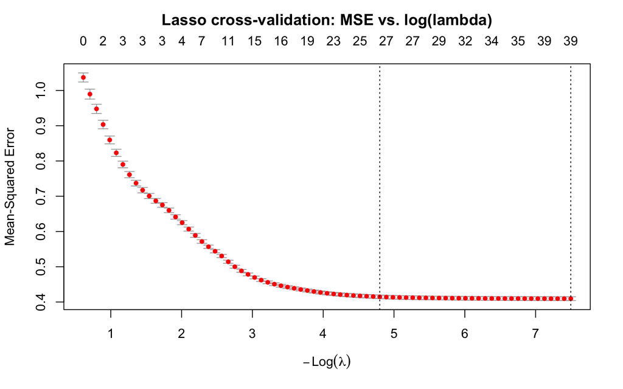

```r
plot(cv_lasso)
title("Lasso cross-validation: MSE vs. log(lambda)", line = 2.5)
```

The dashed vertical lines mark **lambda.min** (minimum CV-MSE) and **lambda.1se** (most regularised model within one standard error). The top axis shows how many non-zero coefficients survive at each $\lambda$.

**Important⚠️ T5: Compare Lasso to OLS on out-of-sample MSE**

1. Read off the CV-MSE at lambda.min and at lambda.1se from the plot (or from `cv_lasso$cvm` at the corresponding indices).
2. How does the CV-MSE at lambda.min compare to the OLS cross-validation results from Step 4?
3. How many variables does Lasso retain at lambda.1se? How many at lambda.min?

**Show code: numerical Lasso vs. OLS comparison**

```r
idx_min <- which(cv_lasso$lambda == lambda_min)
idx_1se <- which(cv_lasso$lambda == lambda_1se)

tibble(
  Method                = c("OLS — baseline",     "OLS — full",
                            "Lasso (lambda.min)", "Lasso (lambda.1se)"),
  `CV-MSE`              = c(cv_results$mean_rmse[1]^2,
                            cv_results$mean_rmse[2]^2,
                            cv_lasso$cvm[idx_min],
                            cv_lasso$cvm[idx_1se]),
  `Non-zero params`     = c(length(coef(mod_baseline_full)) - 1,
                            length(coef(mod_full_spec)) - 1,
                            cv_lasso$nzero[idx_min],
                            cv_lasso$nzero[idx_1se])
) %>%
  mutate(`CV-MSE` = round(`CV-MSE`, 4)) %>%
  gt() %>%
  gt::tab_options(table.font.size = "12px")
```

| Method | CV-MSE | Non-zero params |
| --- | --- | --- |
| OLS — baseline | 0.5127 | 4 |
| OLS — full | 0.4251 | 44 |
| Lasso (lambda.min) | 0.4095 | 39 |
| Lasso (lambda.1se) | 0.4147 | 27 |

**Note🟢 The Lasso payoff (Click to unfold)**

Lasso does the choosing automatically, via the $\lambda$ that cross-validates best.

# 7 Step 6 — Which Variables Survive?

The Lasso coefficients at `lambda.1se` tell us which variables carry prediction power. Variables with zero coefficients have been removed from the model.

```r
coef_lasso <- coef(cv_lasso, s = "lambda.1se")
coef_df <- as_tibble(as.matrix(coef_lasso), rownames = "variable") %>%
                rename(estimate = 2) %>%                # ← position-based, version-proof
                filter(variable != "(Intercept)") %>%
                mutate(retained = estimate != 0)
# count retained vs. removed


# count retained vs. removed
coef_df %>%
  count(retained) %>%
  gt() %>%
  gt::tab_header(title = "Variable selection at lambda.1se") %>%
  gt::tab_options(table.font.size = "12px")
```

Variable selection at lambda.1se

| retained | n |
| --- | --- |
| FALSE | 17 |
| TRUE | 27 |

The retained variables, sorted by magnitude:

**Show code: retained variables sorted**

```r
coef_df %>%
  filter(retained) %>%
  mutate(abs_estimate = abs(estimate)) %>%
  arrange(desc(abs_estimate)) %>%
  select(variable, estimate) %>%
  mutate(estimate = round(estimate, 4)) %>%
  gt() %>%
  gt::tab_options(table.font.size = "11px")
```

| variable | estimate |
| --- | --- |
| log(price) | -2.5246 |
| brandtropicana:age60 | 2.1483 |
| brandtropicana:hval150 | 1.3575 |
| brandtropicana:educ | 1.0712 |
| age60 | 0.9987 |
| brandminute.maid:age60 | 0.8377 |
| feat | 0.7989 |
| brandminute.maid:educ | 0.7932 |
| brandminute.maid:hval150 | 0.6496 |
| ethnic | 0.5368 |
| cpwvol5 | -0.4827 |
| income | -0.2635 |
| workwom | -0.2372 |
| hhlarge | -0.2358 |
| feat:brandminute.maid | 0.2059 |
| feat:brandtropicana | -0.2012 |
| hval150 | -0.1538 |
| brandtropicana:log(price) | 0.1093 |
| brandtropicana | 0.0949 |
| deal | 0.0812 |
| brandtropicana:deal | -0.0512 |
| brandminute.maid:log(price) | 0.0441 |
| cpdist5 | 0.0431 |
| sstrvol | -0.0314 |
| sstrdist | -0.0147 |
| brandtropicana:cpdist5 | 0.0127 |
| brandminute.maid:sstrdist | 0.0036 |

**Important⚠️ T6: Read the Lasso selection**

1. Which type of variable dominates the retained list — marketing levers (feat, deal), prices, demographics, or interactions?
2. Are demographic main effects retained, or mostly the brand × demographic interactions?
3. Compare to your expectation from Step 0: did Variant C deliver what we expected — namely, brand-specific demographic effects?

**Note🟢 What the selection tells us (Click to unfold)**

The lesson: with Lasso, **the data picks the relevant variables**. We do not need to decide in advance which demographics to include — the algorithm tells us, via cross-validation.

**Warning⚠️ Important: Lasso coefficients are NOT causal estimates**

The Lasso has done what we asked: it found the sparse set of variables that best predicts on held-out data. But:

- Lasso **deliberately introduces bias** (this was the whole point)
- The coefficients are **shrunk toward zero** — they understate the true partial effects
- Variable selection is **not the same as causal identification** — Lasso retains predictively useful variables, not causally relevant variables
- Two variables that are highly correlated may both be useful; Lasso arbitrarily picks one (depending on the random seed). The *unselected* variable is not “unimportant”.

**A Lucas-style caveat (recall Lab 1, the BLUE-bridge section).** The Lasso-selected model predicts well *under the same DGP as in the training data*. If Sarah’s stores undergo a regime change — new competitors, new pricing strategies, new demographic shifts — the selected variables may no longer be the right ones. This is the Lucas critique applied to Path P. Prediction is honest about its scope: it is interpolation within a stable structure, not extrapolation across regimes.

**The path forward: sample-splitting.** If we want Lasso (or any ML method) to help with *causal* questions, we need to fix the specification choice before estimation. The technique:

1. Split the data into two parts (typically 50/50)
2. Use part 1 to *select* the variables (Lasso, etc.)
3. Use part 2 to *estimate* the final coefficients with the selected specification

Part 2 has not seen the specification-search. Inference on part 2 is honest — classical SE and CI become interpretable again. This is the principle behind **Double Machine Learning** (Chernozhukov et al. 2018), which Lab 3 develops formally for causal estimation. The institutional argument from Lab 1’s “Note of Caution” (Spiess 2025) is operationalised here: sample-splitting is what *enforces* the unbiasedness restriction in practice.

## 7.1 Translator memo for Sarah

**Important⚠️ T7: Translator memo (Lab 2)**

Draft Sarah’s follow-up memo. Cover:

- Question 1: Did demographics improve the prediction tool? *By how much, and what variables were essential?*
- Question 2: Did demographics change the picture on the advertising effect? *No — the structural feat × deal problem remains.*
- A short statement on the board’s “more variables = better information” intuition: when does it hold, when does it fail?

**3–5 sentences per question, business language.**

# 8 Bonus — For independent study

## 8.1 ⚠️ B1: Ridge vs. Lasso vs. Elastic Net

The three regularisers differ in their penalty geometry. This bonus task compares them on our data.

**Important⚠️ B1: Compare three regularisation approaches**

```r
set.seed(42)

# Ridge: alpha = 0
cv_ridge <- cv.glmnet(X_full, y_full, alpha = 0, nfolds = 5)

# Lasso: alpha = 1 (already fit as cv_lasso)

# Elastic Net: alpha = 0.5
cv_elnet <- cv.glmnet(X_full, y_full, alpha = 0.5, nfolds = 5)

# Compare CV-MSE at lambda.min
tibble::tibble(
  method    = c("Ridge",                  "Lasso",                cv_elnet = "Elastic Net (α = 0.5)"),
  cv_mse    = c(min(cv_ridge$cvm),        min(cv_lasso$cvm),      min(cv_elnet$cvm)),
  n_nonzero = c(sum(coef(cv_ridge, s = "lambda.min") != 0) - 1,
                sum(coef(cv_lasso, s = "lambda.min") != 0) - 1,
                sum(coef(cv_elnet, s = "lambda.min") != 0) - 1)
) %>%
  dplyr::mutate(across(where(is.numeric), \(x) round(x, 4)))
```

1. Which method gives the lowest CV-MSE? By how much?
2. Which method retains the most variables? Which the fewest?
3. What does the trade-off look like — does the method with lowest MSE also retain the most variables, or is there a clear winner on both axes?

## 8.2 ⚠️ B2: A pure-cross-price Lasso (without demographics)

This bonus isolates the role of cross-price information by fitting Lasso on the `tbl_cross` data with only prices, feat and deal — no demographics.

**Important⚠️ B2: Cross-price Lasso**

```r
library(glmnet)

# build a separate model for each of the three brands
for (target_brand in c("dominicks", "minute.maid", "tropicana")) {

  y_brand <- tbl_cross[[paste0("logmove_", target_brand)]]

  X_brand <- tbl_cross %>%
    select(starts_with("price_"), starts_with("feat_"), starts_with("deal_")) %>%
    mutate(across(starts_with("price_"), log)) %>%
    as.matrix()

  cv_b <- cv.glmnet(X_brand, y_brand, alpha = 1, nfolds = 5)

  cat("Brand: ", target_brand, "\n")
  print(coef(cv_b, s = "lambda.1se"))
  cat("\n")
}
```

1. Which cross-prices survive selection for each brand?
2. Do all three brands retain their own price?
3. What does the pattern of retained cross-prices tell you about substitution within the OJ category?

## 8.3 ⚠️ B3: Lasso path visualisation

Plot the full coefficient path as a function of $\lambda$ to see which variables exit the model first.

**Important⚠️ B3: Trace coefficient paths**

```r
fit_lasso <- glmnet(X_full, y_full, alpha = 1)
plot(fit_lasso, xvar = "lambda", label = TRUE)
abline(v = log(cv_lasso$lambda.1se), lty = 2, col = "red")
abline(v = log(cv_lasso$lambda.min), lty = 2, col = "blue")
```

1. Which variables are the last to be shrunk to zero as $\lambda$ increases?
2. Are these the same variables that ended up in the lambda.1se selection from Step 6?
3. What does this picture tell you about the *order* in which variables contribute to prediction?

## 8.4 ⚠️ B4: Big-data regime — would we have done this differently?

In Step 0 we noted that p ≈ 36 takes us close to the big-data regime in spirit but not in scale. This bonus asks what would change if p were truly large (say, p > n).

**Important⚠️ B4: A reflection without code**

Imagine Sarah comes back next year with the full 11-brand price matrix *and* loyalty-card-level customer demographics — say, 200 variables.

This is a written reflection — no R code expected.

## 8.5 ⚠️ B5: Multilevel as the E1 alternative

Lasso is a Path-P tool. For Path E1 — inferential reading — clustered or multilevel models address related concerns more directly.

**Important⚠️ B5: Fit a multilevel model with random intercepts by store**

```r
library(lme4)

mod_lme <- lmer(
  logmove ~ feat + deal + log(price) + brand + income + educ +
    (1 | store),
  data = tbl_full
)

summary(mod_lme)
```

1. How does the `feat` coefficient compare to the OLS estimate from Step 1?
2. What does the random-intercept variance tell us about between-store heterogeneity?
3. Why is this **not** a substitute for the regularisation pathway — what does it add, what doesn’t it address?

# 9 Summary — what we found

[output not shown]

# 10 What comes next

| Lab | Question it answers |
| --- | --- |
| **Lab 3 — A/B-test design + DiD simulation** | If Sarah really wants the causal effect of advertising, how must she set up the study? And what would she do with a natural experiment (Path E2)? |

**What Lab 3 will add to this story.** Lab 1 showed that OVB contaminates the OLS estimate of $\beta_{\text{feat}}$. Lab 2 showed that no amount of Path-P sophistication (Ridge, Lasso, demographic controls) can fix this — they all live in the same DGP. The fix must come from a *different DGP*: a study design that manipulates the treatment instead of observing it.

- **A/B-test design** as the gold standard
- **Difference-in-Differences and Event-Study Designs** as quasi- experimental paths when randomisation is infeasible
- **Instrumental Variables** sneak-peek
- **Double Machine Learning** (Chernozhukov et al. 2018) as the operative answer to the Spiess-style institutional argument from Lab 1’s “Note of Caution”: ML for nuisance modeling, with sample-splitting protecting the causal estimate

The mini-DAG from Lab 1 (`deal` as common cause of `feat` and `logmove`) is the starting point. Lab 3 develops the DAG framework systematically.

## References

Chernozhukov, Victor, Denis Chetverikov, Mert Demirer, Esther Duflo, Christian Hansen, Whitney Newey, and James Robins. 2018. “Double/Debiased Machine Learning for Treatment and Structural Parameters.” *The Econometrics Journal* 21 (1): C1–68. https://doi.org/10.1111/ectj.12097.

Fan, Jianqing, Fang Han, and Han Liu. 2014. “Challenges of Big Data Analysis.” *National Science Review* 1 (2): 293–314. https://doi.org/10.1093/nsr/nwt032.

Kilts Center for Marketing at the University of Chicago Booth School of Business. 2018. “Dominick’s.” https://www.chicagobooth.edu/research/kilts/research-data/dominicks.

Spiess, Jann. 2025. “Optimal Estimation When Researcher and Social Preferences Are Misaligned.” *Econometrica* 93 (5): 1779–1810. https://doi.org/10.3982/ECTA18640.